# Paper 1

Kezia Olive

# Introduction

My project is under the umbrella of **Gendered Pathways to STEM aspiration** project, with this one specifically focusing on **Elementary school students’ expectancy-value profiles in different domains’ association with achievement and STEM aspiration: Longitudinal trajectories and gender differences**.  
In this project, I work with a dataset of primary school students’ interest (Subjective Task Value or STV) towards *math*, *science* and *Finnish* throughout the six years of primary school.  
This study investigated the development patterns of primary school students’ subjective task values in three academic domains: Science, Mathematics and Language (Finnish), taking into account gendered difference and the students’ STEM aspiration at the end of primary school. Data with five time points were collected from students from second grade to sixth grade in Helsinki, Finland.

### Theoretical Framework

This study is framed by the suggested relationships from the expectancy value theory, which posits that a person’s characteristics (in this case, their gender) will affect first their subjective task value, and finally, their academic outcome.

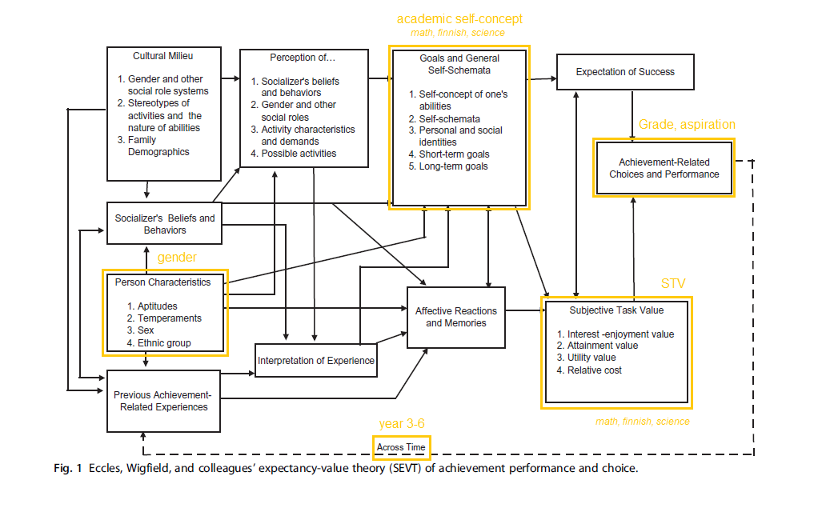

### Variables

The variables to be used in this study are:

- Gender
- STV in math, science & Finnish, throughout 6 years
- Students’ STEM aspiration at year 6

(co-variates):

- Grades at year 6
- Students’ self-concept of ability
- Parental SES

### Research Questions

In this project, we are trying to answer several research questions:

- Are the profiles found by Oppermann 2021 replicable across distinct samples/time points (year 4,5,6)?
- How do students’ characteristics predict their expectancy value profile membership? (Gender differences, SES)
- How are students’ expectancy value profiles associated with their concurrent achievement in math, science and finnish (students’ grades at end of grade 6)?
- How does students’ expectancy value profile membership predict their choice of a STEM career (students’ dream job)?

### R Setup and Data import

```r
library(tidyverse)
library(corrr)
library(lcsm)
library(Rmisc)
library(ggpubr)
library(paletteer)
library(tidyLPA)
library(lavaan)
library(writexl)
library(multiplex)
knitr::opts_knit$set(root.dir = 'c:/LocalData/olivekez/Paper 1')

#load dataset
load("C:/LocalData/olivekez/Paper 1/STLfull1.Rdata") #full data
load("~/Paper 1 - data/Working_data/STL6.Rdata") #wide data with only ID, sex, Asp, and averaged STV
load("C:/LocalData/olivekez/Paper 1/STL6_STVmi.Rdata") #raw data with only ID and STV
```

# Data wrangling

Taking only aggregated STV values (averaged), with ID, sex, and aspiration in sixth year and putting it into the **STL6_full** variable.

## Dataset for Mplus

```r
STLMplus <- STLfulldata1 %>%
  rowwise() %>%
  dplyr::rename(Asp = F_Q46_3) %>%
   select(ID, sex, Asp,
         D_Q11_1, D_Q12_1, D_Q13_1, D_Q14_1, D_Q15_1, D_Q16_1, D_Q17_1, D_Q18_1, D_Q19_1, D_Q20_1, D_Q21_1, D_Q21b_1, D_Q24_1, D_Q25_1, D_Q26_1,
         D_Q11_2, D_Q12_2, D_Q13_2, D_Q14_2, D_Q15_2, D_Q16_2, D_Q17_2, D_Q18_2, D_Q19_2, D_Q20_2, D_Q21_2, D_Q21b_2, D_Q24_2, D_Q25_2, D_Q26_2,
         D_Q11_3, D_Q12_3, D_Q13_3, D_Q14_3, D_Q15_3, D_Q16_3, D_Q17_3, D_Q18_3, D_Q19_3, D_Q20_3, D_Q21_3, D_Q21b_3, D_Q24_3, D_Q25_3, D_Q26_3,
         E_Q11_1, E_Q12_1, E_Q13_1, E_Q14_1, E_Q15_1, E_Q16_1, E_Q17_1, E_Q18_1, E_Q19_1, E_Q20_1, E_Q21_1, E_Q21b_1, E_Q24_1, E_Q25_1, E_Q26_1,
         E_Q11_2, E_Q12_2, E_Q13_2, E_Q14_2, E_Q15_2, E_Q16_2, E_Q17_2, E_Q18_2, E_Q19_2, E_Q20_2, E_Q21_2, E_Q21b_2, E_Q24_2, E_Q25_2, E_Q26_2,
         E_Q11_3, E_Q12_3, E_Q13_3, E_Q14_3, E_Q15_3, E_Q16_3, E_Q17_3, E_Q18_3, E_Q19_3, E_Q20_3, E_Q21_3, E_Q21b_3, E_Q24_3, E_Q25_3, E_Q26_3,
         F_Q11_1, F_Q12_1, F_Q13_1, F_Q14_1, F_Q15_1, F_Q16_1, F_Q17_1, F_Q18_1, F_Q19_1, F_Q20_1, F_Q21_1, F_Q21b_1, F_Q24_1, F_Q25_1, F_Q26_1,
         F_Q11_2, F_Q12_2, F_Q13_2, F_Q14_2, F_Q15_2, F_Q16_2, F_Q17_2, F_Q18_2, F_Q19_2, F_Q20_2, F_Q21_2, F_Q21b_2, F_Q24_2, F_Q25_2, F_Q26_2,
         F_Q11_3, F_Q12_3, F_Q13_3, F_Q14_3, F_Q15_3, F_Q16_3, F_Q17_3, F_Q18_3, F_Q19_3, F_Q20_3, F_Q21_3, F_Q21b_3, F_Q24_3, F_Q25_3, F_Q26_3)

STLMplus[is.na(STLMplus)] <- -999
write_xlsx(STLMplus, "STLMplus.xlsx")
write.dat(STLMplus, "STLMplus.dat")
```

## Aggregated long dataset

```r
#We only need:
#ID, sex,
#STV values (aggregated from three dimensions: ATTainment, UTility, and INTrinsic values),
#and aspiration in sixth year

STL6_full <-
  STLfulldata1 %>%
  rowwise() %>%
  dplyr::rename(Asp = F_Q46_3) %>%
  mutate(B_STV_attS = mean(c(B_Q11_1, B_Q12_1, B_Q13_1), na.rm = TRUE)) %>%
  # B = data from grade 2 | att = attainment value | S = science
  mutate(B_STV_costS = mean(c(B_Q14_1, B_Q15_1, B_Q16_1, B_Q17_1, B_Q18_1, B_Q19_1), na.rm = TRUE)) %>%
  mutate(B_STV_utS = mean(c(B_Q20_1, B_Q21_1, B_Q21b_1), na.rm = TRUE)) %>% # ut = utility value
  mutate(B_STV_intvS = mean(c(B_Q24_1, B_Q25_1, B_Q26_1), na.rm = TRUE)) %>% # intv = intrinsic value
  mutate(B_STV_S = mean(c(B_STV_attS, B_STV_intvS, B_STV_utS), na.rm = TRUE)) %>%
  #taking it together, B_STV_S = STV of year 2 in science: average of attainment, utility, and intrinsic value
  mutate(B_STV_attM = mean(c(B_Q11_2, B_Q12_2, B_Q13_2), na.rm = TRUE)) %>% # M = math
  mutate(B_STV_costM = mean(c(B_Q14_2, B_Q15_2, B_Q16_2, B_Q17_2, B_Q18_2, B_Q19_2), na.rm = TRUE)) %>%
  mutate(B_STV_utM = mean(c(B_Q20_2, B_Q21_2, B_Q21b_2), na.rm = TRUE)) %>%
  mutate(B_STV_intvM = mean(c(B_Q24_2, B_Q25_2, B_Q26_2), na.rm = TRUE)) %>%
  mutate(B_STV_M = mean(c(B_STV_attM, B_STV_intvM, B_STV_utM), na.rm = TRUE)) %>%
  mutate(B_STV_attF = mean(c(B_Q11_3, B_Q12_3, B_Q13_3), na.rm = TRUE)) %>% # F = finnish
  mutate(B_STV_costF = mean(c(B_Q14_3, B_Q15_3, B_Q16_3, B_Q17_3, B_Q18_3, B_Q19_3), na.rm = TRUE)) %>%
  mutate(B_STV_utF = mean(c(B_Q20_3, B_Q21_3, B_Q21b_3), na.rm = TRUE)) %>%
  mutate(B_STV_intvF = mean(c(B_Q24_3, B_Q25_3, B_Q26_3), na.rm = TRUE)) %>%
  mutate(B_STV_F = mean(c(B_STV_attF, B_STV_intvF, B_STV_utF), na.rm = TRUE)) %>%
  mutate(C_STV_attS = mean(c(C_Q11_1, C_Q12_1, C_Q13_1), na.rm = TRUE)) %>% # C = data from grade 3
  mutate(C_STV_costS = mean(c(C_Q14_1, C_Q15_1, C_Q16_1, C_Q17_1, C_Q18_1, C_Q19_1), na.rm = TRUE)) %>%
  mutate(C_STV_utS = mean(c(C_Q20_1, C_Q21_1, C_Q21b_1), na.rm = TRUE)) %>%
  mutate(C_STV_intvS = mean(c(C_Q24_1, C_Q25_1, C_Q26_1), na.rm = TRUE)) %>%
  mutate(C_STV_S = mean(c(C_STV_attS, C_STV_intvS, C_STV_utS), na.rm = TRUE)) %>%
  mutate(C_STV_attM = mean(c(C_Q11_2, C_Q12_2, C_Q13_2), na.rm = TRUE)) %>%
  mutate(C_STV_costM = mean(c(C_Q14_2, C_Q15_2, C_Q16_2, C_Q17_2, C_Q18_2, C_Q19_2), na.rm = TRUE)) %>%
  mutate(C_STV_utM = mean(c(C_Q20_2, C_Q21_2, C_Q21b_2), na.rm = TRUE)) %>%
  mutate(C_STV_intvM = mean(c(C_Q24_2, C_Q25_2, C_Q26_2), na.rm = TRUE)) %>%
  mutate(C_STV_M = mean(c(C_STV_attM, C_STV_intvM, C_STV_utM), na.rm = TRUE)) %>%
  mutate(C_STV_attF = mean(c(C_Q11_3, C_Q12_3, C_Q13_3), na.rm = TRUE)) %>%
  mutate(C_STV_costF = mean(c(C_Q14_3, C_Q15_3, C_Q16_3, C_Q17_3, C_Q18_3, C_Q19_3), na.rm = TRUE)) %>%
  mutate(C_STV_utF = mean(c(C_Q20_3, C_Q21_3, C_Q21b_3), na.rm = TRUE)) %>%
  mutate(C_STV_intvF = mean(c(C_Q24_3, C_Q25_3, C_Q26_3), na.rm = TRUE)) %>%
  mutate(C_STV_F = mean(c(C_STV_attF, C_STV_intvF, C_STV_utF), na.rm = TRUE)) %>%
  mutate(D_STV_attS = mean(c(D_Q11_1, D_Q12_1, D_Q13_1), na.rm = TRUE)) %>% # D = data from grade 4
  mutate(D_STV_costS = mean(c(D_Q14_1, D_Q15_1, D_Q16_1, D_Q17_1, D_Q18_1, D_Q19_1), na.rm = TRUE)) %>%
  mutate(D_STV_utS = mean(c(D_Q20_1, D_Q21_1, D_Q21b_1), na.rm = TRUE)) %>%
  mutate(D_STV_intvS = mean(c(D_Q24_1, D_Q25_1, D_Q26_1), na.rm = TRUE)) %>%
  mutate(D_STV_S = mean(c(D_STV_attS, D_STV_intvS, D_STV_utS), na.rm = TRUE)) %>%
  mutate(D_STV_attM = mean(c(D_Q11_2, D_Q12_2, D_Q13_2), na.rm = TRUE)) %>%
  mutate(D_STV_costM = mean(c(D_Q14_2, D_Q15_2, D_Q16_2, D_Q17_2, D_Q18_2, D_Q19_2), na.rm = TRUE)) %>%
  mutate(D_STV_utM = mean(c(D_Q20_2, D_Q21_2, D_Q21b_2), na.rm = TRUE)) %>%
  mutate(D_STV_intvM = mean(c(D_Q24_2, D_Q25_2, D_Q26_2), na.rm = TRUE)) %>%
  mutate(D_STV_M = mean(c(D_STV_attM, D_STV_intvM, D_STV_utM), na.rm = TRUE)) %>%
  mutate(D_STV_attF = mean(c(D_Q11_3, D_Q12_3, D_Q13_3), na.rm = TRUE)) %>%
  mutate(D_STV_costF = mean(c(D_Q14_3, D_Q15_3, D_Q16_3, D_Q17_3, D_Q18_3, D_Q19_3), na.rm = TRUE)) %>%
  mutate(D_STV_utF = mean(c(D_Q20_3, D_Q21_3, D_Q21b_3), na.rm = TRUE)) %>%
  mutate(D_STV_intvF = mean(c(D_Q24_3, D_Q25_3, D_Q26_3), na.rm = TRUE)) %>%
  mutate(D_STV_F = mean(c(D_STV_attF, D_STV_intvF, D_STV_utF), na.rm = TRUE)) %>%
  mutate(E_STV_attS = mean(c(E_Q11_1, E_Q12_1, E_Q13_1), na.rm = TRUE)) %>% # E = grade 5
  mutate(E_STV_costS = mean(c(E_Q14_1, E_Q15_1, E_Q16_1, E_Q17_1, E_Q18_1, E_Q19_1), na.rm = TRUE)) %>%
  mutate(E_STV_utS = mean(c(E_Q20_1, E_Q21_1, E_Q21b_1), na.rm = TRUE)) %>%
  mutate(E_STV_intvS = mean(c(E_Q24_1, E_Q25_1, E_Q26_1), na.rm = TRUE)) %>%
  mutate(E_STV_S = mean(c(E_STV_attS, E_STV_intvS, E_STV_utS), na.rm = TRUE)) %>%
  mutate(E_STV_attM = mean(c(E_Q11_2, E_Q12_2, E_Q13_2), na.rm = TRUE)) %>%
  mutate(E_STV_costM = mean(c(E_Q14_2, E_Q15_2, E_Q16_2, E_Q17_2, E_Q18_2, E_Q19_2), na.rm = TRUE)) %>%
  mutate(E_STV_utM = mean(c(E_Q20_2, E_Q21_2, E_Q21b_2), na.rm = TRUE)) %>%
  mutate(E_STV_intvM = mean(c(E_Q24_2, E_Q25_2, E_Q26_2), na.rm = TRUE)) %>%
  mutate(E_STV_M = mean(c(E_STV_attM, E_STV_intvM, E_STV_utM), na.rm = TRUE)) %>%
  mutate(E_STV_attF = mean(c(E_Q11_3, E_Q12_3, E_Q13_3), na.rm = TRUE)) %>%
  mutate(E_STV_costF = mean(c(E_Q14_3, E_Q15_3, E_Q16_3, E_Q17_3, E_Q18_3, E_Q19_3), na.rm = TRUE)) %>%
  mutate(E_STV_utF = mean(c(E_Q20_3, E_Q21_3, E_Q21b_3), na.rm = TRUE)) %>%
  mutate(E_STV_intvF = mean(c(E_Q24_3, E_Q25_3, E_Q26_3), na.rm = TRUE)) %>%
  mutate(E_STV_F = mean(c(E_STV_attF, E_STV_intvF, E_STV_utF), na.rm = TRUE)) %>%
  mutate(F_STV_attS = mean(c(F_Q11_1, F_Q12_1, F_Q13_1), na.rm = TRUE)) %>% # F = grade 6
  mutate(F_STV_costS = mean(c(F_Q14_1, F_Q15_1, F_Q16_1, F_Q17_1, F_Q18_1, F_Q19_1), na.rm = TRUE)) %>%
  mutate(F_STV_utS = mean(c(F_Q20_1, F_Q21_1, F_Q21b_1), na.rm = TRUE)) %>%
  mutate(F_STV_intvS = mean(c(F_Q24_1, F_Q25_1, F_Q26_1), na.rm = TRUE)) %>%
  mutate(F_STV_S = mean(c(F_STV_attS, F_STV_intvS, F_STV_utS), na.rm = TRUE)) %>%
  mutate(F_STV_attM = mean(c(F_Q11_2, F_Q12_2, F_Q13_2), na.rm = TRUE)) %>%
  mutate(F_STV_costM = mean(c(F_Q14_2, F_Q15_2, F_Q16_2, F_Q17_2, F_Q18_2, F_Q19_2), na.rm = TRUE)) %>%
  mutate(F_STV_utM = mean(c(F_Q20_2, F_Q21_2, F_Q21b_2), na.rm = TRUE)) %>%
  mutate(F_STV_intvM = mean(c(F_Q24_2, F_Q25_2, F_Q26_2), na.rm = TRUE)) %>%
  mutate(F_STV_M = mean(c(F_STV_attM, F_STV_intvM, F_STV_utM), na.rm = TRUE)) %>%
  mutate(F_STV_attF = mean(c(F_Q11_3, F_Q12_3, F_Q13_3), na.rm = TRUE)) %>%
  mutate(F_STV_costF = mean(c(F_Q14_3, F_Q15_3, F_Q16_3, F_Q17_3, F_Q18_3, F_Q19_3), na.rm = TRUE)) %>%
  mutate(F_STV_utF = mean(c(F_Q20_3, F_Q21_3, F_Q21b_3), na.rm = TRUE)) %>%
  mutate(F_STV_intvF = mean(c(F_Q24_3, F_Q25_3, F_Q26_3), na.rm = TRUE)) %>%
  mutate(F_STV_F = mean(c(F_STV_attF, F_STV_intvF, F_STV_utF), na.rm = TRUE)) %>%
  select(ID, sex, Asp,
         B_STV_S, B_STV_M, B_STV_F,
         C_STV_S, C_STV_M, C_STV_F,
         D_STV_S, D_STV_M, D_STV_F,
         E_STV_S, E_STV_M, E_STV_F,
         F_STV_S, F_STV_M, F_STV_F)


#long dataset
STL6_long <-pivot_longer(STL6_full,
                       cols = -c(ID, sex, Asp),
                       names_to = c("wave", ".value", "domain"),
                       names_pattern = ("(.)_(.*)_(.)"))

STL6_long$STV[STL6_long$STV == 0] <- NA

#mutating each relevant variable to factor
STL6_long <-
  STL6_long %>%
  mutate(sex = factor(sex, levels = c(1,2),
                      labels = c("Girl", "Boy"))) %>%
  mutate(wave = factor(wave, levels = c("B", "C", "D", "E", "F"),
                       labels = c("year2", "year3", "year4", "year5", "year6"))) %>%
  mutate(Asp = factor(Asp, levels = c(0,1,2),
                      labels = c("No STEM", "STEM Prof", "STEM Sup"))) %>%
  mutate(domain = factor(domain, levels = c("S","M","F"),
                      labels = c("Science", "Math", "Language")))
```

## Not aggregated dataset

```r
STL6_na <-
  STLfulldata1 %>%
  rowwise() %>%
  dplyr::rename(Asp = F_Q46_3) %>%
  mutate(B_STV_at_S = mean(c(B_Q11_1, B_Q12_1, B_Q13_1), na.rm = TRUE)) %>%
  # B = data from grade 2 | att = attainment value | S = science
  mutate(B_STV_co_S = mean(c(B_Q14_1, B_Q15_1, B_Q16_1, B_Q17_1, B_Q18_1, B_Q19_1), na.rm = TRUE)) %>%
  mutate(B_STV_ut_S = mean(c(B_Q20_1, B_Q21_1, B_Q21b_1), na.rm = TRUE)) %>% # ut = utility value
  mutate(B_STV_in_S = mean(c(B_Q24_1, B_Q25_1, B_Q26_1), na.rm = TRUE)) %>% # intv = intrinsic value
  mutate(B_STV_at_M = mean(c(B_Q11_2, B_Q12_2, B_Q13_2), na.rm = TRUE)) %>% # M = math
  mutate(B_STV_co_M = mean(c(B_Q14_2, B_Q15_2, B_Q16_2, B_Q17_2, B_Q18_2, B_Q19_2), na.rm = TRUE)) %>%
  mutate(B_STV_ut_M = mean(c(B_Q20_2, B_Q21_2, B_Q21b_2), na.rm = TRUE)) %>%
  mutate(B_STV_in_M = mean(c(B_Q24_2, B_Q25_2, B_Q26_2), na.rm = TRUE)) %>%
  mutate(B_STV_at_F = mean(c(B_Q11_3, B_Q12_3, B_Q13_3), na.rm = TRUE)) %>% # F = finnish
  mutate(B_STV_co_F = mean(c(B_Q14_3, B_Q15_3, B_Q16_3, B_Q17_3, B_Q18_3, B_Q19_3), na.rm = TRUE)) %>%
  mutate(B_STV_ut_F = mean(c(B_Q20_3, B_Q21_3, B_Q21b_3), na.rm = TRUE)) %>%
  mutate(B_STV_in_F = mean(c(B_Q24_3, B_Q25_3, B_Q26_3), na.rm = TRUE)) %>%
  mutate(C_STV_at_S = mean(c(C_Q11_1, C_Q12_1, C_Q13_1), na.rm = TRUE)) %>% # C = data from grade 3
  mutate(C_STV_co_S = mean(c(C_Q14_1, C_Q15_1, C_Q16_1, C_Q17_1, C_Q18_1, C_Q19_1), na.rm = TRUE)) %>%
  mutate(C_STV_ut_S = mean(c(C_Q20_1, C_Q21_1, C_Q21b_1), na.rm = TRUE)) %>%
  mutate(C_STV_in_S = mean(c(C_Q24_1, C_Q25_1, C_Q26_1), na.rm = TRUE)) %>%
  mutate(C_STV_at_M = mean(c(C_Q11_2, C_Q12_2, C_Q13_2), na.rm = TRUE)) %>%
  mutate(C_STV_co_M = mean(c(C_Q14_2, C_Q15_2, C_Q16_2, C_Q17_2, C_Q18_2, C_Q19_2), na.rm = TRUE)) %>%
  mutate(C_STV_ut_M = mean(c(C_Q20_2, C_Q21_2, C_Q21b_2), na.rm = TRUE)) %>%
  mutate(C_STV_in_M = mean(c(C_Q24_2, C_Q25_2, C_Q26_2), na.rm = TRUE)) %>%
  mutate(C_STV_at_F = mean(c(C_Q11_3, C_Q12_3, C_Q13_3), na.rm = TRUE)) %>%
  mutate(C_STV_co_F = mean(c(C_Q14_3, C_Q15_3, C_Q16_3, C_Q17_3, C_Q18_3, C_Q19_3), na.rm = TRUE)) %>%
  mutate(C_STV_ut_F = mean(c(C_Q20_3, C_Q21_3, C_Q21b_3), na.rm = TRUE)) %>%
  mutate(C_STV_in_F = mean(c(C_Q24_3, C_Q25_3, C_Q26_3), na.rm = TRUE)) %>%
  mutate(D_STV_at_S = mean(c(D_Q11_1, D_Q12_1, D_Q13_1), na.rm = TRUE)) %>% # D = data from grade 4
  mutate(D_STV_co_S = mean(c(D_Q14_1, D_Q15_1, D_Q16_1, D_Q17_1, D_Q18_1, D_Q19_1), na.rm = TRUE)) %>%
  mutate(D_STV_ut_S = mean(c(D_Q20_1, D_Q21_1, D_Q21b_1), na.rm = TRUE)) %>%
  mutate(D_STV_in_S = mean(c(D_Q24_1, D_Q25_1, D_Q26_1), na.rm = TRUE)) %>%
  mutate(D_STV_at_M = mean(c(D_Q11_2, D_Q12_2, D_Q13_2), na.rm = TRUE)) %>%
  mutate(D_STV_co_M = mean(c(D_Q14_2, D_Q15_2, D_Q16_2, D_Q17_2, D_Q18_2, D_Q19_2), na.rm = TRUE)) %>%
  mutate(D_STV_ut_M = mean(c(D_Q20_2, D_Q21_2, D_Q21b_2), na.rm = TRUE)) %>%
  mutate(D_STV_in_M = mean(c(D_Q24_2, D_Q25_2, D_Q26_2), na.rm = TRUE)) %>%
  mutate(D_STV_at_F = mean(c(D_Q11_3, D_Q12_3, D_Q13_3), na.rm = TRUE)) %>%
  mutate(D_STV_co_F = mean(c(D_Q14_3, D_Q15_3, D_Q16_3, D_Q17_3, D_Q18_3, D_Q19_3), na.rm = TRUE)) %>%
  mutate(D_STV_ut_F = mean(c(D_Q20_3, D_Q21_3, D_Q21b_3), na.rm = TRUE)) %>%
  mutate(D_STV_in_F = mean(c(D_Q24_3, D_Q25_3, D_Q26_3), na.rm = TRUE)) %>%
  mutate(E_STV_at_S = mean(c(E_Q11_1, E_Q12_1, E_Q13_1), na.rm = TRUE)) %>% # E = grade 5
  mutate(E_STV_co_S = mean(c(E_Q14_1, E_Q15_1, E_Q16_1, E_Q17_1, E_Q18_1, E_Q19_1), na.rm = TRUE)) %>%
  mutate(E_STV_ut_S = mean(c(E_Q20_1, E_Q21_1, E_Q21b_1), na.rm = TRUE)) %>%
  mutate(E_STV_in_S = mean(c(E_Q24_1, E_Q25_1, E_Q26_1), na.rm = TRUE)) %>%
  mutate(E_STV_at_M = mean(c(E_Q11_2, E_Q12_2, E_Q13_2), na.rm = TRUE)) %>%
  mutate(E_STV_co_M = mean(c(E_Q14_2, E_Q15_2, E_Q16_2, E_Q17_2, E_Q18_2, E_Q19_2), na.rm = TRUE)) %>%
  mutate(E_STV_ut_M = mean(c(E_Q20_2, E_Q21_2, E_Q21b_2), na.rm = TRUE)) %>%
  mutate(E_STV_in_M = mean(c(E_Q24_2, E_Q25_2, E_Q26_2), na.rm = TRUE)) %>%
  mutate(E_STV_at_F = mean(c(E_Q11_3, E_Q12_3, E_Q13_3), na.rm = TRUE)) %>%
  mutate(E_STV_co_F = mean(c(E_Q14_3, E_Q15_3, E_Q16_3, E_Q17_3, E_Q18_3, E_Q19_3), na.rm = TRUE)) %>%
  mutate(E_STV_ut_F = mean(c(E_Q20_3, E_Q21_3, E_Q21b_3), na.rm = TRUE)) %>%
  mutate(E_STV_in_F = mean(c(E_Q24_3, E_Q25_3, E_Q26_3), na.rm = TRUE)) %>%
  mutate(F_STV_at_S = mean(c(F_Q11_1, F_Q12_1, F_Q13_1), na.rm = TRUE)) %>% # F = grade 6
  mutate(F_STV_co_S = mean(c(F_Q14_1, F_Q15_1, F_Q16_1, F_Q17_1, F_Q18_1, F_Q19_1), na.rm = TRUE)) %>%
  mutate(F_STV_ut_S = mean(c(F_Q20_1, F_Q21_1, F_Q21b_1), na.rm = TRUE)) %>%
  mutate(F_STV_in_S = mean(c(F_Q24_1, F_Q25_1, F_Q26_1), na.rm = TRUE)) %>%
  mutate(F_STV_at_M = mean(c(F_Q11_2, F_Q12_2, F_Q13_2), na.rm = TRUE)) %>%
  mutate(F_STV_co_M = mean(c(F_Q14_2, F_Q15_2, F_Q16_2, F_Q17_2, F_Q18_2, F_Q19_2), na.rm = TRUE)) %>%
  mutate(F_STV_ut_M = mean(c(F_Q20_2, F_Q21_2, F_Q21b_2), na.rm = TRUE)) %>%
  mutate(F_STV_in_M = mean(c(F_Q24_2, F_Q25_2, F_Q26_2), na.rm = TRUE)) %>%
  mutate(F_STV_at_F = mean(c(F_Q11_3, F_Q12_3, F_Q13_3), na.rm = TRUE)) %>%
  mutate(F_STV_co_F = mean(c(F_Q14_3, F_Q15_3, F_Q16_3, F_Q17_3, F_Q18_3, F_Q19_3), na.rm = TRUE)) %>%
  mutate(F_STV_ut_F = mean(c(F_Q20_3, F_Q21_3, F_Q21b_3), na.rm = TRUE)) %>%
  mutate(F_STV_in_F = mean(c(F_Q24_3, F_Q25_3, F_Q26_3), na.rm = TRUE)) %>%
  select(ID, sex, Asp,
         B_STV_at_S, B_STV_co_S, B_STV_ut_S, B_STV_in_S,
         B_STV_at_M, B_STV_co_M, B_STV_ut_M, B_STV_in_M,
         B_STV_at_F, B_STV_co_F, B_STV_ut_F, B_STV_in_F,
         C_STV_at_S, C_STV_co_S, C_STV_ut_S, C_STV_in_S,
         C_STV_at_M, C_STV_co_M, C_STV_ut_M, C_STV_in_M,
         C_STV_at_F, C_STV_co_F, C_STV_ut_F, C_STV_in_F,
         D_STV_at_S, D_STV_co_S, D_STV_ut_S, D_STV_in_S,
         D_STV_at_M, D_STV_co_M, D_STV_ut_M, D_STV_in_M,
         D_STV_at_F, D_STV_co_F, D_STV_ut_F, D_STV_in_F,
         E_STV_at_S, E_STV_co_S, E_STV_ut_S, E_STV_in_S,
         E_STV_at_M, E_STV_co_M, E_STV_ut_M, E_STV_in_M,
         E_STV_at_F, E_STV_co_F, E_STV_ut_F, E_STV_in_F,
         F_STV_at_S, F_STV_co_S, F_STV_ut_S, F_STV_in_S,
         F_STV_at_M, F_STV_co_M, F_STV_ut_M, F_STV_in_M,
         F_STV_at_F, F_STV_co_F, F_STV_ut_F, F_STV_in_F)

#long dataset
STL6_long2 <-pivot_longer(STL6_na,
                       cols = -c(ID, sex, Asp),
                       names_to = c("wave", ".value", "domain"),
                       names_pattern = ("(.)_STV_(.*)_(.)"))

#mutating each relevant variable to factor
STL6_long2 <-
  STL6_long2 %>%
  mutate(sex = factor(sex, levels = c(1,2),
                      labels = c("Girl", "Boy"))) %>%
  mutate(wave = factor(wave, levels = c("B", "C", "D", "E", "F"),
                       labels = c("year2", "year3", "year4", "year5", "year6"))) %>%
  mutate(Asp = factor(Asp, levels = c(0,1,2),
                      labels = c("No STEM", "STEM Prof", "STEM Sup"))) %>%
  mutate(domain = factor(domain, levels = c("S","M","F"),
                      labels = c("Science", "Math", "Language")))
```

## Counting number of participants

```r
STL6_long2 <- STL6_long2 %>%
  mutate(STVfreq = factor(is.nan(at),levels = c("FALSE", "TRUE"), labels = c("Yes", "NA")))

STL6_long2 %>%
  group_by(domain, wave) %>%
  filter(STVfreq == "Yes") %>%
  dplyr::count(STVfreq)
```

```
## # A tibble: 15 x 4
## # Groups:   domain, wave [15]
##    domain   wave  STVfreq     n
##    <fct>    <fct> <fct>   <int>
##  1 Science  year2 Yes       307
##  2 Science  year3 Yes       366
##  3 Science  year4 Yes       268
##  4 Science  year5 Yes       360
##  5 Science  year6 Yes       355
##  6 Math     year2 Yes       306
##  7 Math     year3 Yes       366
##  8 Math     year4 Yes       268
##  9 Math     year5 Yes       360
## 10 Math     year6 Yes       356
## 11 Language year2 Yes       306
## 12 Language year3 Yes       365
## 13 Language year4 Yes       268
## 14 Language year5 Yes       358
## 15 Language year6 Yes       354
```

```r
#checking the N of each year, how many overlaps
```

# Descriptive Visualization

## Plotting according to RQ

Here are plots representing the average development of each subject’s STV throughout the school years

```r
STL6_longc <- summarySE(STL6_long, measurevar="STV", groupvars= c("domain", "wave"), na.rm = T)

STL6_longc
```

```
##      domain  wave   N      STV        sd         se         ci
## 1   Science year2 308 3.962662 0.7908007 0.04506005 0.08866562
## 2   Science year3 366 3.867183 0.8174753 0.04273012 0.08402812
## 3   Science year4 268 3.653607 0.8930031 0.05454884 0.10740060
## 4   Science year5 360 3.578704 0.8657300 0.04562798 0.08973171
## 5   Science year6 356 3.484941 0.8846981 0.04688891 0.09221495
## 6      Math year2 307 4.227832 0.6511746 0.03716450 0.07313032
## 7      Math year3 366 4.294019 0.6701817 0.03503096 0.06888785
## 8      Math year4 268 4.005597 0.7728448 0.04720901 0.09294928
## 9      Math year5 360 3.923302 0.8177847 0.04310104 0.08476224
## 10     Math year6 356 3.745943 0.8646293 0.04582526 0.09012312
## 11 Language year2 307 4.036374 0.7657897 0.04370593 0.08600220
## 12 Language year3 365 4.092846 0.7381460 0.03863633 0.07597843
## 13 Language year4 268 3.849502 0.8168596 0.04989764 0.09824290
## 14 Language year5 359 3.669607 0.8123469 0.04287403 0.08431661
## 15 Language year6 356 3.421660 0.9302025 0.04930063 0.09695802
```

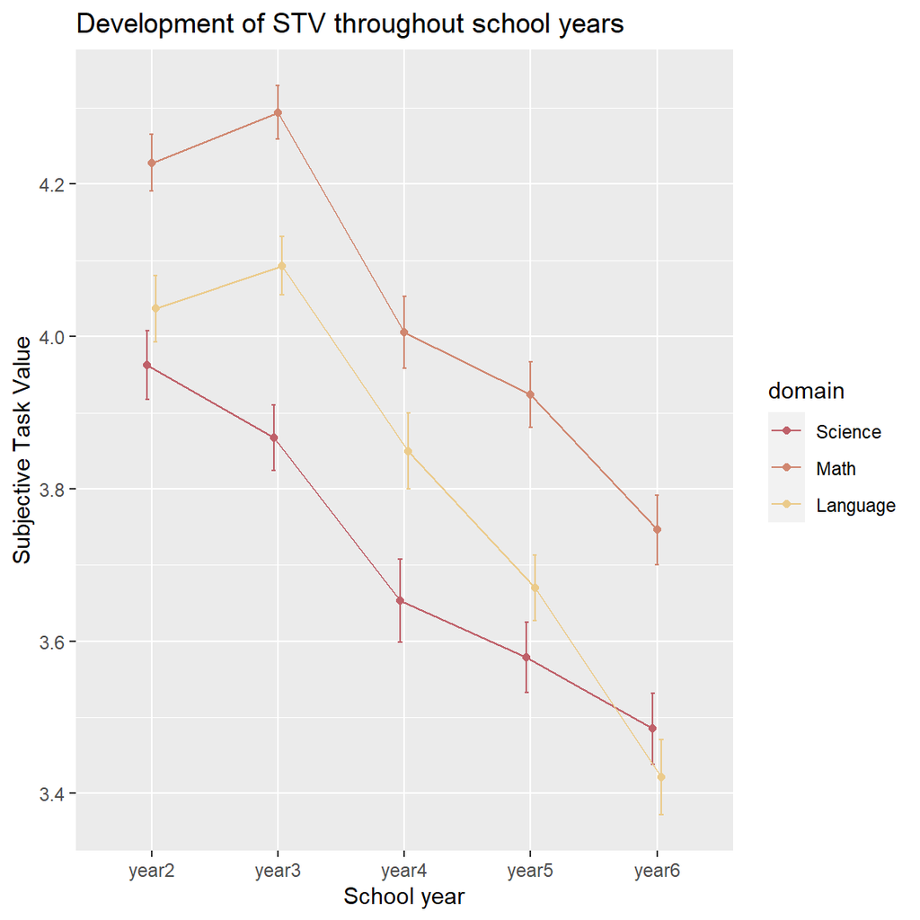

```r
pd <- position_dodge(0.1) # move them .05 to the left and right

ggplot(STL6_longc, aes(x=wave, y=STV, color=domain, group=domain)) +
  geom_errorbar(aes(ymin=STV-se, ymax=STV+se), width=.1, position=pd) +
  geom_line(position=pd) +
  geom_point(position=pd) +
  scale_color_paletteer_d("nord::aurora") +
  labs(x = "School year", y = "Subjective Task Value", title = "Development of STV throughout school years")
```

Here is a box and violin plot showing the distribution of the data in each subject throughout the year:

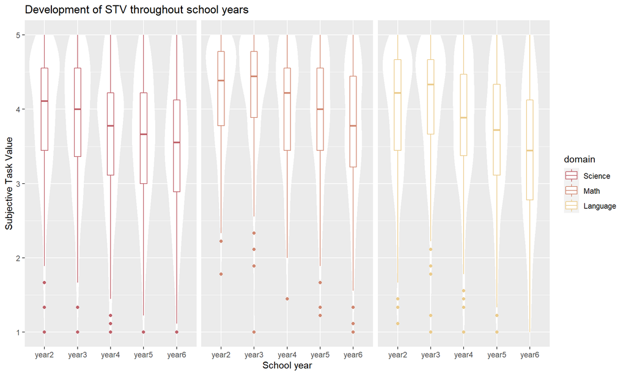

```r
ggplot(STL6_long, aes(wave, STV, color = domain)) +
  geom_violin(color="white") +
  geom_boxplot(width=.2) +
  scale_color_paletteer_d("nord::aurora") +
  facet_wrap(~domain)+
  labs(x = "School year", y = "Subjective Task Value", title = "Development of STV throughout school years") +
  theme(strip.background = element_blank(), strip.text.x = element_blank())
```

From these plots, we can see that there are slight decreases of Subjective Task Value in all school subjects throughout time. It is interesting to see that compared to the other subjects, students seems to value Math in all years, even if the trajectory is decreasing on average.

## Plotting gendered difference in STV development

```r
#data summary
STL6_longc1 <- summarySE(STL6_long, measurevar="STV", groupvars= c("sex", "wave", "domain"), na.rm = T)
STL6_longc1
```

```
##     sex  wave   domain   N      STV        sd         se         ci
## 1  Girl year2  Science 179 4.063315 0.7707403 0.05760783 0.11368220
## 2  Girl year2     Math 179 4.201738 0.6419641 0.04798265 0.09468805
## 3  Girl year2 Language 179 4.122905 0.6904810 0.05160897 0.10184416
## 4  Girl year3  Science 203 3.939518 0.8283349 0.05813771 0.11463462
## 5  Girl year3     Math 203 4.277230 0.7064580 0.04958363 0.09776789
## 6  Girl year3 Language 203 4.225780 0.6720102 0.04716587 0.09300060
## 7  Girl year4  Science 147 3.692744 0.8778401 0.07240303 0.14309341
## 8  Girl year4     Math 147 3.997732 0.7729486 0.06375173 0.12599545
## 9  Girl year4 Language 147 3.919501 0.7962628 0.06567465 0.12979581
## 10 Girl year5  Science 200 3.536389 0.8754674 0.06190490 0.12207377
## 11 Girl year5     Math 200 3.801389 0.8381942 0.05926928 0.11687645
## 12 Girl year5 Language 200 3.683056 0.8132380 0.05750461 0.11339660
## 13 Girl year6  Science 192 3.486690 0.9079097 0.06552274 0.12924111
## 14 Girl year6     Math 192 3.717882 0.8474739 0.06116116 0.12063806
```

[output cut: 31 more lines]

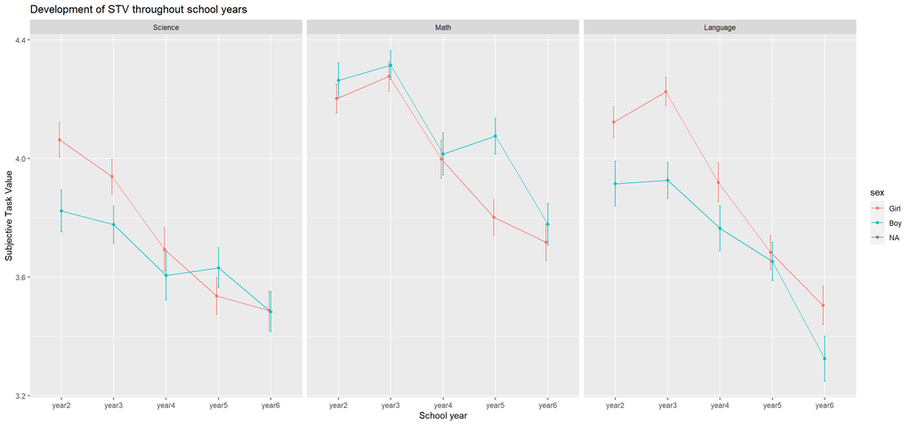

```r
#lineplot
ggplot(STL6_longc1, aes(x=wave, y=STV, color=sex, group=sex)) +
  geom_errorbar(aes(ymin=STV-se, ymax=STV+se), width=.1, position=pd) +
  geom_line(position=pd) +
  geom_point(position=pd) +
  facet_wrap(~domain) +
  labs(x = "School year", y = "Subjective Task Value", title = "Development of STV throughout school years")
```

Here is a box and violin plot showing the distribution of the data for each gender throughout the year:

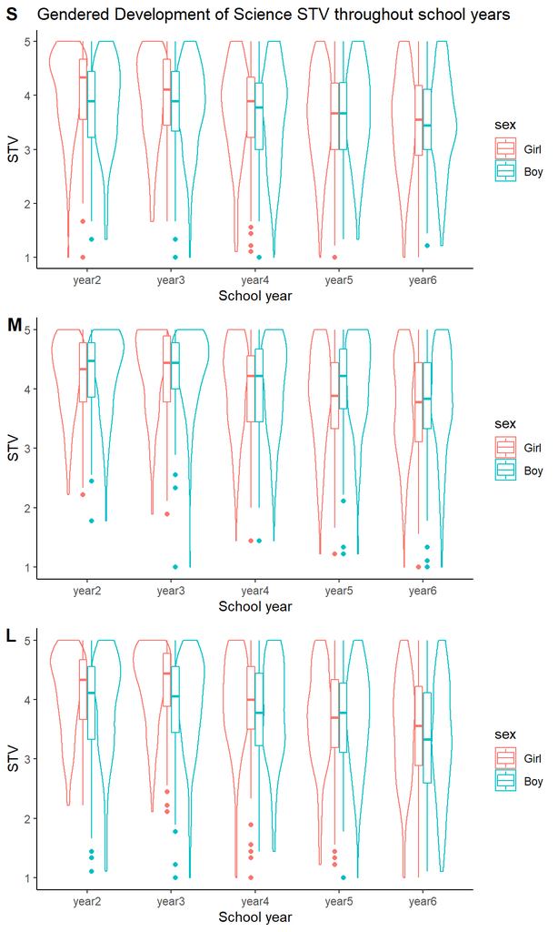

```r
#Plotting each domain per gender:
##Science STV development

STL6_long_S <- filter(STL6_long, domain == "Science")

Plot_science <- ggplot(STL6_long_S, aes(wave, STV, color = sex)) +
  geom_violin() +
  geom_boxplot(width=.2) + theme_classic() +
  labs(x = "School year", y = "STV", title = "Gendered Development of Science STV throughout school years")

##Math STV development

STL6_long_M <- filter(STL6_long, domain == "Math")

Plot_math <- ggplot(STL6_long_M, aes(wave, STV, color = sex)) +
  geom_violin() +
  geom_boxplot(width=.2) + theme_classic()+
  labs(x = "School year", y = "STV")

#Finnish STV development

STL6_long_L <- filter(STL6_long, domain == "Language")

Plot_lang <- ggplot(STL6_long_L, aes(wave, STV, color = sex)) +
  geom_violin() +
  geom_boxplot(width=.2) + theme_classic()+
  labs(x = "School year", y = "STV")

#All plots
ggarrange(Plot_science, Plot_math, Plot_lang,
          labels = c("S", "M", "L"),
          ncol = 1)
```

These plots also showed that there seems to be slight gender difference in how girls and boys’ STV develop in each subject.

# CFA - items

## Year 4

```r
#Science
m4s <- ' at4 =~ D_Q11_1 + D_Q12_1 + D_Q13_1
co4 =~ D_Q14_1 + D_Q15_1 + D_Q16_1 + D_Q17_1 + D_Q18_1 + D_Q19_1
ut4 =~ D_Q20_1 + D_Q21_1 + D_Q21b_1
in4 =~ D_Q24_1 + D_Q25_1 + D_Q26_1 '

fit4s <- cfa(m4s, data=STLfulldata1)

summary(fit4s, fit.measures=T)
```

```
## lavaan 0.6-9 ended normally after 44 iterations
##
##   Estimator                                         ML
##   Optimization method                           NLMINB
##   Number of model parameters                        36
##
##                                                   Used       Total
##   Number of observations                           236         700
##
## Model Test User Model:
##
##   Test statistic                               151.729
##   Degrees of freedom                                84
##   P-value (Chi-square)                           0.000
##
## Model Test Baseline Model:
##
##   Test statistic                              1714.763
##   Degrees of freedom                               105
##   P-value                                        0.000
##
## User Model versus Baseline Model:
##
##   Comparative Fit Index (CFI)                    0.958
##   Tucker-Lewis Index (TLI)                       0.947
##
## Loglikelihood and Information Criteria:
##
##   Loglikelihood user model (H0)              -4906.112
##   Loglikelihood unrestricted model (H1)      -4830.248
##
##   Akaike (AIC)                                9884.225
##   Bayesian (BIC)                             10008.923
##   Sample-size adjusted Bayesian (BIC)         9894.817
##
## Root Mean Square Error of Approximation:
##
##   RMSEA                                          0.058
##   90 Percent confidence interval - lower         0.043
##   90 Percent confidence interval - upper         0.073
```

[output cut: 52 more lines]

```
##    .D_Q15_1           0.571    0.080    7.151    0.000
##    .D_Q16_1           0.697    0.073    9.562    0.000
##    .D_Q17_1           0.827    0.077   10.798    0.000
##    .D_Q18_1           1.094    0.120    9.133    0.000
##    .D_Q19_1           1.256    0.133    9.481    0.000
##    .D_Q20_1           0.924    0.105    8.824    0.000
##    .D_Q21_1           1.275    0.128    9.990    0.000
##    .D_Q21b_1          0.298    0.077    3.855    0.000
##    .D_Q24_1           0.255    0.041    6.240    0.000
##    .D_Q25_1           0.377    0.048    7.810    0.000
##    .D_Q26_1           0.382    0.048    7.884    0.000
##     at4               0.301    0.057    5.301    0.000
##     co4               0.824    0.152    5.407    0.000
##     ut4               0.868    0.154    5.636    0.000
##     in4               1.326    0.148    8.989    0.000
```

```r
#Math
m4m <- ' at4 =~ D_Q11_2 + D_Q12_2 + D_Q13_2
co4 =~ D_Q14_2 + D_Q15_2 + D_Q16_2 + D_Q17_2 + D_Q18_2 + D_Q19_2
ut4 =~ D_Q20_2 + D_Q21_2 + D_Q21b_2
in4 =~ D_Q24_2 + D_Q25_2 + D_Q26_2 '

fit4m <- cfa(m4m, data=STLfulldata1)

summary(fit4m, fit.measures=T)
```

```
## lavaan 0.6-9 ended normally after 54 iterations
##
##   Estimator                                         ML
##   Optimization method                           NLMINB
##   Number of model parameters                        36
##
##                                                   Used       Total
##   Number of observations                           233         700
##
## Model Test User Model:
##
##   Test statistic                               110.859
##   Degrees of freedom                                84
##   P-value (Chi-square)                           0.026
##
## Model Test Baseline Model:
##
##   Test statistic                              1584.916
##   Degrees of freedom                               105
##   P-value                                        0.000
##
## User Model versus Baseline Model:
##
##   Comparative Fit Index (CFI)                    0.982
##   Tucker-Lewis Index (TLI)                       0.977
##
## Loglikelihood and Information Criteria:
##
##   Loglikelihood user model (H0)              -4726.585
##   Loglikelihood unrestricted model (H1)      -4671.156
##
##   Akaike (AIC)                                9525.171
##   Bayesian (BIC)                              9649.408
##   Sample-size adjusted Bayesian (BIC)         9535.306
##
## Root Mean Square Error of Approximation:
##
##   RMSEA                                          0.037
##   90 Percent confidence interval - lower         0.013
##   90 Percent confidence interval - upper         0.055
```

[output cut: 52 more lines]

```
##    .D_Q15_2           0.668    0.080    8.360    0.000
##    .D_Q16_2           0.584    0.065    9.047    0.000
##    .D_Q17_2           1.034    0.096   10.742    0.000
##    .D_Q18_2           0.747    0.094    7.977    0.000
##    .D_Q19_2           1.192    0.122    9.742    0.000
##    .D_Q20_2           0.856    0.110    7.802    0.000
##    .D_Q21_2           1.309    0.129   10.186    0.000
##    .D_Q21b_2          0.434    0.069    6.241    0.000
##    .D_Q24_2           0.253    0.042    5.995    0.000
##    .D_Q25_2           0.313    0.044    7.030    0.000
##    .D_Q26_2           0.458    0.053    8.620    0.000
##     at4               0.097    0.025    3.942    0.000
##     co4               0.887    0.160    5.539    0.000
##     ut4               0.649    0.137    4.724    0.000
##     in4               1.543    0.168    9.163    0.000
```

```r
#Finnish
m4f <- ' at4 =~ D_Q11_3 + D_Q12_3 + D_Q13_3
co4 =~ D_Q14_3 + D_Q15_3 + D_Q16_3 + D_Q17_3 + D_Q18_3 + D_Q19_3
ut4 =~ D_Q20_3 + D_Q21_3 + D_Q21b_3
in4 =~ D_Q24_3 + D_Q25_3 + D_Q26_3 '

fit4f <- cfa(m4f, data=STLfulldata1)

summary(fit4f, fit.measures=T)
```

```
## lavaan 0.6-9 ended normally after 43 iterations
##
##   Estimator                                         ML
##   Optimization method                           NLMINB
##   Number of model parameters                        36
##
##                                                   Used       Total
##   Number of observations                           234         700
##
## Model Test User Model:
##
##   Test statistic                               158.154
##   Degrees of freedom                                84
##   P-value (Chi-square)                           0.000
##
## Model Test Baseline Model:
##
##   Test statistic                              1626.651
##   Degrees of freedom                               105
##   P-value                                        0.000
##
## User Model versus Baseline Model:
##
##   Comparative Fit Index (CFI)                    0.951
##   Tucker-Lewis Index (TLI)                       0.939
##
## Loglikelihood and Information Criteria:
##
##   Loglikelihood user model (H0)              -4746.426
##   Loglikelihood unrestricted model (H1)      -4667.349
##
##   Akaike (AIC)                                9564.853
##   Bayesian (BIC)                              9689.244
##   Sample-size adjusted Bayesian (BIC)         9575.141
##
## Root Mean Square Error of Approximation:
##
##   RMSEA                                          0.061
##   90 Percent confidence interval - lower         0.047
##   90 Percent confidence interval - upper         0.076
```

[output cut: 52 more lines]

```
##    .D_Q15_3           0.680    0.081    8.425    0.000
##    .D_Q16_3           0.474    0.053    8.890    0.000
##    .D_Q17_3           0.832    0.077   10.794    0.000
##    .D_Q18_3           1.048    0.116    9.049    0.000
##    .D_Q19_3           1.226    0.126    9.708    0.000
##    .D_Q20_3           0.813    0.097    8.347    0.000
##    .D_Q21_3           1.148    0.115    9.962    0.000
##    .D_Q21b_3          0.365    0.081    4.483    0.000
##    .D_Q24_3           0.325    0.042    7.664    0.000
##    .D_Q25_3           0.273    0.043    6.340    0.000
##    .D_Q26_3           0.340    0.044    7.694    0.000
##     at4               0.266    0.054    4.940    0.000
##     co4               0.911    0.155    5.889    0.000
##     ut4               0.705    0.134    5.270    0.000
##     in4               1.149    0.136    8.432    0.000
```

## Year 5

```r
#Science
m5s <- ' at5 =~ E_Q11_1 + E_Q12_1 + E_Q13_1
co5 =~ E_Q14_1 + E_Q15_1 + E_Q16_1 + E_Q17_1 + E_Q18_1 + E_Q19_1
ut5 =~ E_Q20_1 + E_Q21_1 + E_Q21b_1
in5 =~ E_Q24_1 + E_Q25_1 + E_Q26_1 '

fit5s <- cfa(m5s, data=STLfulldata1)

summary(fit5s, fit.measures=T)
```

```
## lavaan 0.6-9 ended normally after 44 iterations
##
##   Estimator                                         ML
##   Optimization method                           NLMINB
##   Number of model parameters                        36
##
##                                                   Used       Total
##   Number of observations                           324         700
##
## Model Test User Model:
##
##   Test statistic                               226.081
##   Degrees of freedom                                84
##   P-value (Chi-square)                           0.000
##
## Model Test Baseline Model:
##
##   Test statistic                              2557.773
##   Degrees of freedom                               105
##   P-value                                        0.000
##
## User Model versus Baseline Model:
##
##   Comparative Fit Index (CFI)                    0.942
##   Tucker-Lewis Index (TLI)                       0.928
##
## Loglikelihood and Information Criteria:
##
##   Loglikelihood user model (H0)              -6453.000
##   Loglikelihood unrestricted model (H1)      -6339.959
##
##   Akaike (AIC)                               12978.000
##   Bayesian (BIC)                             13114.106
##   Sample-size adjusted Bayesian (BIC)        12999.918
##
## Root Mean Square Error of Approximation:
##
##   RMSEA                                          0.072
##   90 Percent confidence interval - lower         0.061
##   90 Percent confidence interval - upper         0.084
```

[output cut: 52 more lines]

```
##    .E_Q15_1           0.541    0.055    9.757    0.000
##    .E_Q16_1           0.362    0.035   10.319    0.000
##    .E_Q17_1           0.909    0.073   12.487    0.000
##    .E_Q18_1           0.809    0.076   10.653    0.000
##    .E_Q19_1           0.893    0.080   11.219    0.000
##    .E_Q20_1           0.879    0.080   10.970    0.000
##    .E_Q21_1           0.955    0.083   11.500    0.000
##    .E_Q21b_1          0.228    0.066    3.474    0.001
##    .E_Q24_1           0.364    0.043    8.520    0.000
##    .E_Q25_1           0.304    0.039    7.833    0.000
##    .E_Q26_1           0.458    0.047    9.740    0.000
##     at5               0.361    0.056    6.446    0.000
##     co5               1.005    0.127    7.908    0.000
##     ut5               0.674    0.108    6.210    0.000
##     in5               1.362    0.136    9.990    0.000
```

```r
#Math
m5m <- ' at5 =~ E_Q11_2 + E_Q12_2 + E_Q13_2
co5 =~ E_Q14_2 + E_Q15_2 + E_Q16_2 + E_Q17_2 + E_Q18_2 + E_Q19_2
ut5 =~ E_Q20_2 + E_Q21_2 + E_Q21b_2
in5 =~ E_Q24_2 + E_Q25_2 + E_Q26_2 '

fit5m <- cfa(m5m, data=STLfulldata1)

summary(fit5m, fit.measures=T)
```

```
## lavaan 0.6-9 ended normally after 45 iterations
##
##   Estimator                                         ML
##   Optimization method                           NLMINB
##   Number of model parameters                        36
##
##                                                   Used       Total
##   Number of observations                           324         700
##
## Model Test User Model:
##
##   Test statistic                               188.311
##   Degrees of freedom                                84
##   P-value (Chi-square)                           0.000
##
## Model Test Baseline Model:
##
##   Test statistic                              2734.111
##   Degrees of freedom                               105
##   P-value                                        0.000
##
## User Model versus Baseline Model:
##
##   Comparative Fit Index (CFI)                    0.960
##   Tucker-Lewis Index (TLI)                       0.950
##
## Loglikelihood and Information Criteria:
##
##   Loglikelihood user model (H0)              -6367.441
##   Loglikelihood unrestricted model (H1)      -6273.286
##
##   Akaike (AIC)                               12806.882
##   Bayesian (BIC)                             12942.989
##   Sample-size adjusted Bayesian (BIC)        12828.801
##
## Root Mean Square Error of Approximation:
##
##   RMSEA                                          0.062
##   90 Percent confidence interval - lower         0.050
##   90 Percent confidence interval - upper         0.074
```

[output cut: 52 more lines]

```
##    .E_Q15_2           0.454    0.052    8.757    0.000
##    .E_Q16_2           0.546    0.050   11.014    0.000
##    .E_Q17_2           1.398    0.111   12.548    0.000
##    .E_Q18_2           0.911    0.081   11.213    0.000
##    .E_Q19_2           1.078    0.092   11.714    0.000
##    .E_Q20_2           0.943    0.088   10.747    0.000
##    .E_Q21_2           0.961    0.083   11.596    0.000
##    .E_Q21b_2          0.210    0.055    3.838    0.000
##    .E_Q24_2           0.285    0.033    8.681    0.000
##    .E_Q25_2           0.193    0.030    6.532    0.000
##    .E_Q26_2           0.391    0.038   10.173    0.000
##     at5               0.154    0.029    5.366    0.000
##     co5               1.395    0.151    9.238    0.000
##     ut5               0.554    0.103    5.393    0.000
##     in5               1.484    0.139   10.659    0.000
```

```r
#Finnish
m5f <- ' at5 =~ E_Q11_3 + E_Q12_3 + E_Q13_3
co5 =~ E_Q14_3 + E_Q15_3 + E_Q16_3 + E_Q17_3 + E_Q18_3 + E_Q19_3
ut5 =~ E_Q20_3 + E_Q21_3 + E_Q21b_3
in5 =~ E_Q24_3 + E_Q25_3 + E_Q26_3 '

fit5f <- cfa(m5f, data=STLfulldata1)

summary(fit5f, fit.measures=T)
```

```
## lavaan 0.6-9 ended normally after 45 iterations
##
##   Estimator                                         ML
##   Optimization method                           NLMINB
##   Number of model parameters                        36
##
##                                                   Used       Total
##   Number of observations                           321         700
##
## Model Test User Model:
##
##   Test statistic                               184.980
##   Degrees of freedom                                84
##   P-value (Chi-square)                           0.000
##
## Model Test Baseline Model:
##
##   Test statistic                              2358.512
##   Degrees of freedom                               105
##   P-value                                        0.000
##
## User Model versus Baseline Model:
##
##   Comparative Fit Index (CFI)                    0.955
##   Tucker-Lewis Index (TLI)                       0.944
##
## Loglikelihood and Information Criteria:
##
##   Loglikelihood user model (H0)              -6469.573
##   Loglikelihood unrestricted model (H1)      -6377.083
##
##   Akaike (AIC)                               13011.146
##   Bayesian (BIC)                             13146.918
##   Sample-size adjusted Bayesian (BIC)        13032.732
##
## Root Mean Square Error of Approximation:
##
##   RMSEA                                          0.061
##   90 Percent confidence interval - lower         0.049
##   90 Percent confidence interval - upper         0.073
```

[output cut: 52 more lines]

```
##    .E_Q15_3           0.540    0.060    9.029    0.000
##    .E_Q16_3           0.510    0.048   10.669    0.000
##    .E_Q17_3           1.146    0.092   12.522    0.000
##    .E_Q18_3           0.885    0.083   10.646    0.000
##    .E_Q19_3           0.972    0.084   11.645    0.000
##    .E_Q20_3           1.021    0.096   10.679    0.000
##    .E_Q21_3           0.986    0.083   11.818    0.000
##    .E_Q21b_3          0.231    0.062    3.721    0.000
##    .E_Q24_3           0.302    0.037    8.185    0.000
##    .E_Q25_3           0.216    0.032    6.714    0.000
##    .E_Q26_3           0.490    0.047   10.370    0.000
##     at5               0.337    0.055    6.180    0.000
##     co5               1.057    0.131    8.045    0.000
##     ut5               0.773    0.127    6.075    0.000
##     in5               1.198    0.119   10.037    0.000
```

## Year 6

```r
#Science
m6s <- ' at6 =~ F_Q11_1 + F_Q12_1 + F_Q13_1
co6 =~ F_Q14_1 + F_Q15_1 + F_Q16_1 + F_Q17_1 + F_Q18_1 + F_Q19_1
ut6 =~ F_Q20_1 + F_Q21_1 + F_Q21b_1
in6 =~ F_Q24_1 + F_Q25_1 + F_Q26_1 '

fit6s <- cfa(m6s, data=STLfulldata1)

summary(fit6s, fit.measures=T)
```

```
## lavaan 0.6-9 ended normally after 39 iterations
##
##   Estimator                                         ML
##   Optimization method                           NLMINB
##   Number of model parameters                        36
##
##                                                   Used       Total
##   Number of observations                           322         700
##
## Model Test User Model:
##
##   Test statistic                               171.298
##   Degrees of freedom                                84
##   P-value (Chi-square)                           0.000
##
## Model Test Baseline Model:
##
##   Test statistic                              2511.602
##   Degrees of freedom                               105
##   P-value                                        0.000
##
## User Model versus Baseline Model:
##
##   Comparative Fit Index (CFI)                    0.964
##   Tucker-Lewis Index (TLI)                       0.955
##
## Loglikelihood and Information Criteria:
##
##   Loglikelihood user model (H0)              -6372.244
##   Loglikelihood unrestricted model (H1)      -6286.595
##
##   Akaike (AIC)                               12816.488
##   Bayesian (BIC)                             12952.372
##   Sample-size adjusted Bayesian (BIC)        12838.185
##
## Root Mean Square Error of Approximation:
##
##   RMSEA                                          0.057
##   90 Percent confidence interval - lower         0.045
##   90 Percent confidence interval - upper         0.069
```

[output cut: 52 more lines]

```
##    .F_Q15_1           0.436    0.053    8.280    0.000
##    .F_Q16_1           0.485    0.046   10.525    0.000
##    .F_Q17_1           0.717    0.058   12.277    0.000
##    .F_Q18_1           0.827    0.077   10.736    0.000
##    .F_Q19_1           0.928    0.082   11.374    0.000
##    .F_Q20_1           0.672    0.072    9.357    0.000
##    .F_Q21_1           1.026    0.092   11.196    0.000
##    .F_Q21b_1          0.409    0.061    6.741    0.000
##    .F_Q24_1           0.332    0.040    8.377    0.000
##    .F_Q25_1           0.308    0.039    7.839    0.000
##    .F_Q26_1           0.472    0.049    9.619    0.000
##     at6               0.477    0.065    7.375    0.000
##     co6               0.865    0.117    7.418    0.000
##     ut6               0.782    0.113    6.942    0.000
##     in6               1.159    0.118    9.793    0.000
```

```r
#Math
m6m <- ' at6 =~ F_Q11_2 + F_Q12_2 + F_Q13_2
co6 =~ F_Q14_2 + F_Q15_2 + F_Q16_2 + F_Q17_2 + F_Q18_2 + F_Q19_2
ut6 =~ F_Q20_2 + F_Q21_2 + F_Q21b_2
in6 =~ F_Q24_2 + F_Q25_2 + F_Q26_2 '

fit6m <- cfa(m6m, data=STLfulldata1)

summary(fit6m, fit.measures=T)
```

```
## lavaan 0.6-9 ended normally after 41 iterations
##
##   Estimator                                         ML
##   Optimization method                           NLMINB
##   Number of model parameters                        36
##
##                                                   Used       Total
##   Number of observations                           326         700
##
## Model Test User Model:
##
##   Test statistic                               181.871
##   Degrees of freedom                                84
##   P-value (Chi-square)                           0.000
##
## Model Test Baseline Model:
##
##   Test statistic                              2738.651
##   Degrees of freedom                               105
##   P-value                                        0.000
##
## User Model versus Baseline Model:
##
##   Comparative Fit Index (CFI)                    0.963
##   Tucker-Lewis Index (TLI)                       0.954
##
## Loglikelihood and Information Criteria:
##
##   Loglikelihood user model (H0)              -6559.788
##   Loglikelihood unrestricted model (H1)      -6468.852
##
##   Akaike (AIC)                               13191.575
##   Bayesian (BIC)                             13327.904
##   Sample-size adjusted Bayesian (BIC)        13213.714
##
## Root Mean Square Error of Approximation:
##
##   RMSEA                                          0.060
##   90 Percent confidence interval - lower         0.048
##   90 Percent confidence interval - upper         0.072
```

[output cut: 52 more lines]

```
##    .F_Q15_2           0.518    0.060    8.674    0.000
##    .F_Q16_2           0.624    0.058   10.673    0.000
##    .F_Q17_2           1.013    0.081   12.497    0.000
##    .F_Q18_2           0.843    0.079   10.657    0.000
##    .F_Q19_2           0.966    0.084   11.533    0.000
##    .F_Q20_2           0.728    0.073    9.965    0.000
##    .F_Q21_2           0.813    0.076   10.672    0.000
##    .F_Q21b_2          0.345    0.053    6.507    0.000
##    .F_Q24_2           0.294    0.038    7.660    0.000
##    .F_Q25_2           0.345    0.040    8.555    0.000
##    .F_Q26_2           0.428    0.046    9.356    0.000
##     at6               0.237    0.036    6.507    0.000
##     co6               1.184    0.148    8.020    0.000
##     ut6               0.648    0.102    6.340    0.000
##     in6               1.584    0.148   10.670    0.000
```

```r
#Finnish
m6f <- ' at6 =~ F_Q11_3 + F_Q12_3 + F_Q13_3
co6 =~ F_Q14_3 + F_Q15_3 + F_Q16_3 + F_Q17_3 + F_Q18_3 + F_Q19_3
ut6 =~ F_Q20_3 + F_Q21_3 + F_Q21b_3
in6 =~ F_Q24_3 + F_Q25_3 + F_Q26_3 '

fit6f <- cfa(m6f, data=STLfulldata1)

summary(fit6f, fit.measures=T)
```

```
## lavaan 0.6-9 ended normally after 45 iterations
##
##   Estimator                                         ML
##   Optimization method                           NLMINB
##   Number of model parameters                        36
##
##                                                   Used       Total
##   Number of observations                           321         700
##
## Model Test User Model:
##
##   Test statistic                               234.027
##   Degrees of freedom                                84
##   P-value (Chi-square)                           0.000
##
## Model Test Baseline Model:
##
##   Test statistic                              2736.022
##   Degrees of freedom                               105
##   P-value                                        0.000
##
## User Model versus Baseline Model:
##
##   Comparative Fit Index (CFI)                    0.943
##   Tucker-Lewis Index (TLI)                       0.929
##
## Loglikelihood and Information Criteria:
##
##   Loglikelihood user model (H0)              -6627.362
##   Loglikelihood unrestricted model (H1)      -6510.348
##
##   Akaike (AIC)                               13326.724
##   Bayesian (BIC)                             13462.496
##   Sample-size adjusted Bayesian (BIC)        13348.309
##
## Root Mean Square Error of Approximation:
##
##   RMSEA                                          0.075
##   90 Percent confidence interval - lower         0.063
##   90 Percent confidence interval - upper         0.086
```

[output cut: 52 more lines]

```
##    .F_Q15_3           0.512    0.063    8.185    0.000
##    .F_Q16_3           0.775    0.070   11.030    0.000
##    .F_Q17_3           0.836    0.068   12.278    0.000
##    .F_Q18_3           0.910    0.086   10.535    0.000
##    .F_Q19_3           0.957    0.084   11.387    0.000
##    .F_Q20_3           0.747    0.075   10.021    0.000
##    .F_Q21_3           0.910    0.079   11.445    0.000
##    .F_Q21b_3          0.291    0.055    5.265    0.000
##    .F_Q24_3           0.380    0.042    9.076    0.000
##    .F_Q25_3           0.242    0.036    6.737    0.000
##    .F_Q26_3           0.409    0.044    9.374    0.000
##     at6               0.438    0.066    6.635    0.000
##     co6               1.177    0.162    7.261    0.000
##     ut6               1.056    0.137    7.691    0.000
##     in6               1.265    0.130    9.757    0.000
```

# Measurement invariance

Done in Mplus - check folder **“Measurement Invariance”** for input and output files.

| Model | Chi-Sq | df | p | CFI | TLI | 90% CI RMSEA | SRMR |
| --- | --- | --- | --- | --- | --- | --- | --- |
| Configural S | 588.368 | 270 | .000 | .941 | .923 | .044/.055 | .167 |
| Weak Metric S | 604.045 | 282 | .000 | .940 | .925 | .044/.054 | .167 |
| Strong scalar S | 551.746 | 288 | .000 | .951 | .940 | .038/.049 | .125 |
| Residual var S | 581.233 | 306 | .000 | .949 | .941 | .038/.049 | .124 |
| Configural M | 906.328 | 270 | .000 | .878 | .841 | .065/.076 | .384 |
| Weak Metric M | 927.707 | 282 | .000 | .876 | .845 | .064/.074 | .387 |
| Strong scalar M | 722.642 | 288 | .000 | .916 | .898 | .051/.062 | .306 |
| Residual var M | 764.140 | 306 | .000 | .912 | .899 | .051/.061 | .308 |
| Configural F | 561.882 | 270 | .000 | .942 | .925 | .042/.053 | .186 |
| Weak Metric F | 580.053 | 282 | .000 | .941 | .927 | .042/.053 | .193 |
| Strong scalar F | 524.618 | 288 | .000 | .953 | .943 | .036/.047 | .149 |
| Residual var F | 551.960 | 306 | .000 | .952 | .944 | .036/.047 | .152 |

# LGA-Model

These RQs will be examined using Latent Growth Analysis, by treating STV development throughout the years as a latent variable (consisting of attainment, utility, and intrinsic values – see figure below) that predict aspiration, while its intercept and slope being predicted by gender.

This is the model we are trying to achieve:

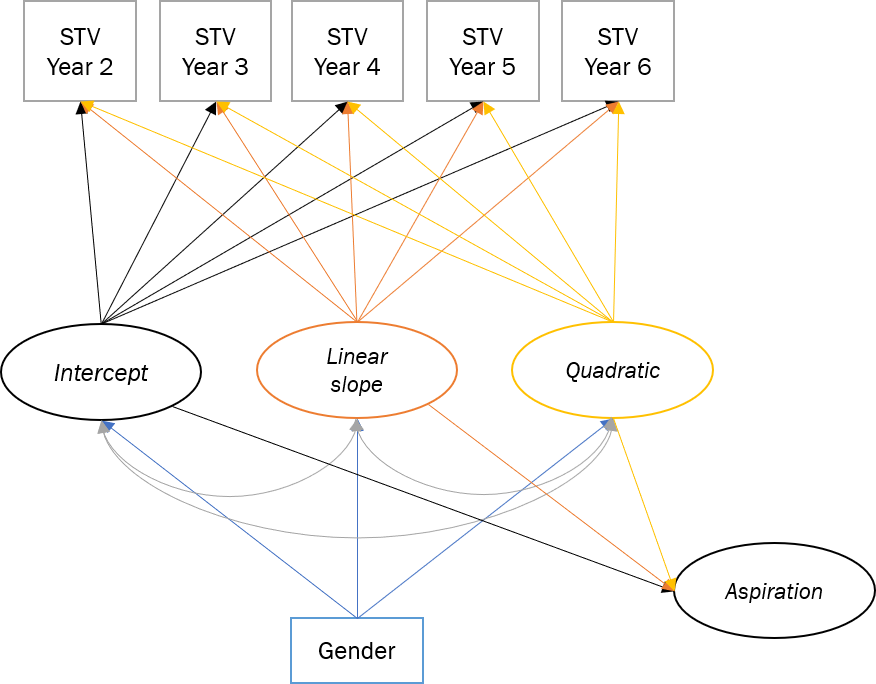

Checking CFA in MPlus (check file STL6 - CFA model)

| Subject | Waves | Issue |
| --- | --- | --- |
| Finnish | 2,6 | NA |
| Finnish | 4,6 | NA |
| Finnish | 5,6 | NA |
| Finnish | 2,3,6 | NA |
| Finnish | 2,4,5 | NA |
| Finnish | 2,5,6 | F_INT6 |
| Finnish | 3,5,6 | F_INT6 |
| Finnish | 4,5,6 | F_INT6 |
| Finnish | 2,3,4,5 | NA |
| Finnish | 2,3,4,6 | NA |
| Finnish | 2,3,4,5,6 | F_INT6 |
| Math | 5,6 | NA |
| Math | 2,5,6 | NA |
| Math | 3,5,6 | NA |
| Math | 4,5,6 | M_UT6 |
| Math | 2,3,4,5 | NA |
| Math | 2,3,4,6 | NA |
| Math | 2,3,5,6 | NA |
| Math | 3,4,5,6 | M_UT6 |
| Math | 2,3,4,5,6 | M_INT5 |
| Science | 3,5 | NA |
| Science | 3,6 | NA |
| Science | 4,5 | S_INT5 |
| Science | 4,6 | NA |
| Science | 5,6 | NA |
| Science | 2,3,4 | NA |
| Science | 2,3,5 | NA |
| Science | 2,3,6 | NA |
| Science | 2,5,6 | S_UT6 |
| Science | 3,5,6 | S_UT6 |
| Science | 4,5,6 | S_ATT6 |
| Science | 2,3,4,5 | S_INT5 |
| Science | 2,3,4,6 | NA |

With the issues of linear dependency, we won’t be able to move forward with the LGA approach, so we are now taking the person-oriented approach.

# LPA approach

### Fourth grade profiles

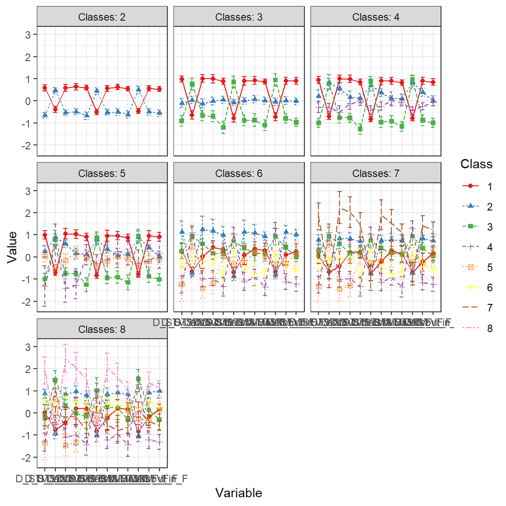

```r
#starting from 4th grade, check the best solution for the profiles
#use standardized values

#trying out fourth grade, standardized values
LPA4 <- STL6_na %>%
  select(D_STV_at_S, D_STV_co_S, D_STV_ut_S, D_STV_in_S,
         D_STV_at_M, D_STV_co_M, D_STV_ut_M, D_STV_in_M,
         D_STV_at_F, D_STV_co_F, D_STV_ut_F, D_STV_in_F) %>%
  scale()%>%
  single_imputation() %>%
  estimate_profiles(2:8)

plot_profiles(LPA4, ci= 0.95, sd=F, rawdata =F, add_line = T)
```

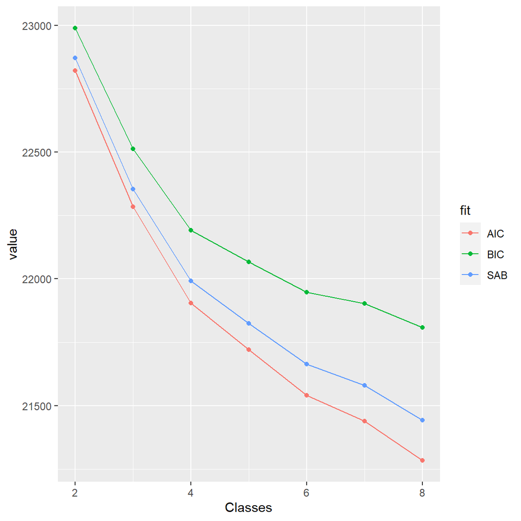

```r
fit_LPA4 <- get_fit(LPA4)

fit_long <- fit_LPA4 %>%
  select(Classes, AIC, BIC, SABIC) %>%
  pivot_longer(cols = -c(Classes),
                       names_to = "fit",
                       names_pattern = ("(...)"))

#Elbow plot
fit_long %>%
  ggplot(aes(Classes, value, group = fit, color = fit)) +
  geom_point() +
  geom_line()
```

### Fifth grade profiles

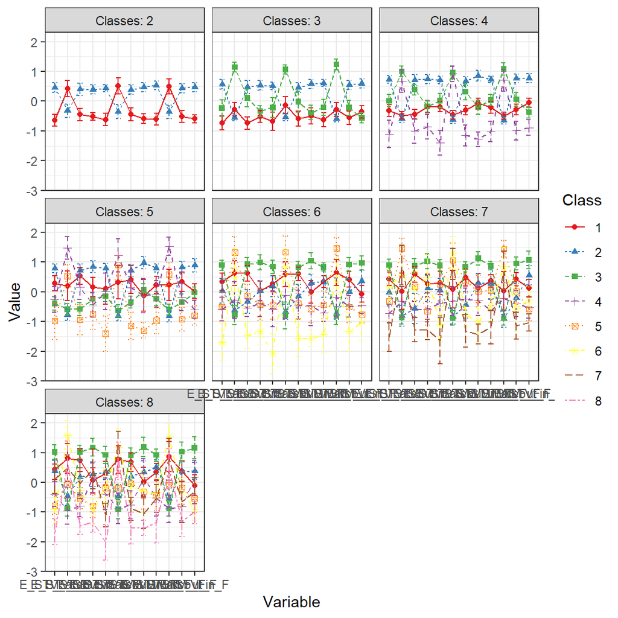

```r
LPA5 <- STL6_na %>%
   select(E_STV_at_S, E_STV_co_S, E_STV_ut_S, E_STV_in_S,
          E_STV_at_M, E_STV_co_M, E_STV_ut_M, E_STV_in_M,
          E_STV_at_F, E_STV_co_F, E_STV_ut_F, E_STV_in_F) %>%
  scale() %>%
  single_imputation() %>%
  estimate_profiles(2:8)

plot_profiles(LPA5, ci= 0.95, sd=F, rawdata =F, add_line = T)
```

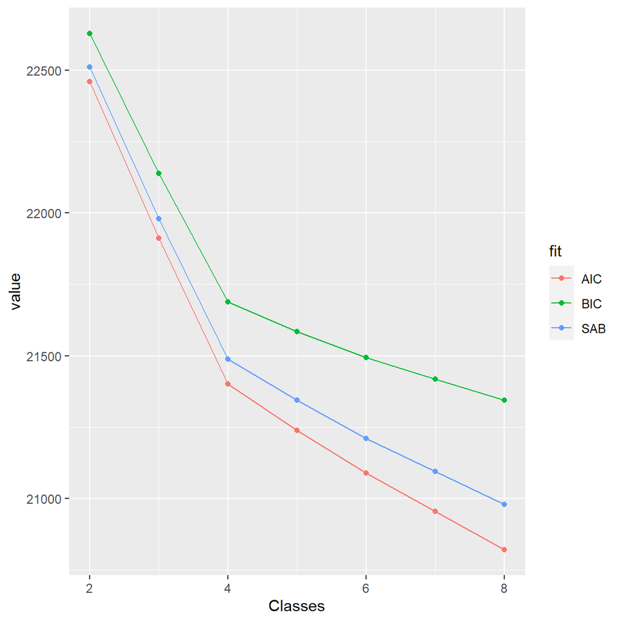

```r
fit_LPA5 <- get_fit(LPA5)

fit_long2 <- fit_LPA5 %>%
  select(Classes, AIC, BIC, SABIC) %>%
  pivot_longer(cols = -c(Classes),
                       names_to = "fit",
                       names_pattern = ("(...)"))

#Elbow plot
fit_long2 %>%
  ggplot(aes(Classes, value, group = fit, color = fit)) +
  geom_point() +
  geom_line()
```

### Sixth grade profiles

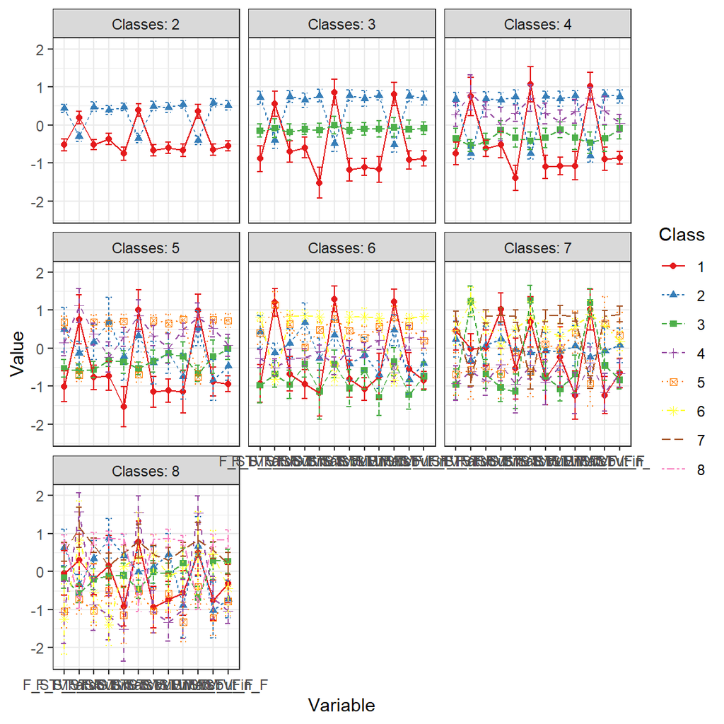

```r
LPA6 <- STL6_na %>%
   select(F_STV_at_S, F_STV_co_S, F_STV_ut_S, F_STV_in_S,
          F_STV_at_M, F_STV_co_M, F_STV_ut_M, F_STV_in_M,
          F_STV_at_F, F_STV_co_F, F_STV_ut_F, F_STV_in_F) %>%
  scale() %>%
  single_imputation() %>%
  estimate_profiles(2:8)

plot_profiles(LPA6, ci= 0.95, sd=F, rawdata =F, add_line = T)
```

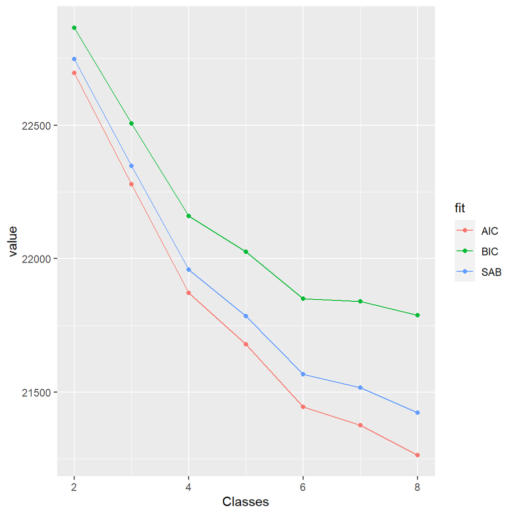

```r
fit_LPA6 <- get_fit(LPA6)

fit_long3 <- fit_LPA6 %>%
  select(Classes, AIC, BIC, SABIC) %>%
  pivot_longer(cols = -c(Classes),
                       names_to = "fit",
                       names_pattern = ("(...)"))

#Elbow plot
fit_long3 %>%
  ggplot(aes(Classes, value, group = fit, color = fit)) +
  geom_point() +
  geom_line()
```